# Data Incuabor Capstone Project

Task: the goal is to come up with a data driven algorithm that attribute portion of the conversion wherever there is one to each marketing channel and customer journey position in the customer journey

Initial thoughts: Model to build 1) random forest 2)regularized linear regression Need to create new varaibles to seperate journey_step according to mkgchannelid

## Read the dataset

```r
journey <- read.csv("journey_data.csv")
```

## Find out atrributes

```r
attributes <- colnames(journey)
attributes
```

```
##  [1] "X"                  "advertiserid"       "journey_id"
##  [4] "event_date_time"    "maxdate"            "journey_event_type"
##  [7] "journey_step"       "mkt_channel_id"     "mkg_channel_typeid"
## [10] "conversion_typeid"  "country"            "msa"
## [13] "city"               "state_or_region"
```

Predictors: journey_step, mktchannelid Result: journey_eventtype

Journey_eventtypye is a two level factor. Both journeystep and mktchannelid are integers.

```r
head(journey)
```

```
##   X advertiserid journey_id     event_date_time
## 1 1          435     372810 2016-10-21 00:45:44
## 2 2          435    1584509 2016-12-14 19:57:05
## 3 3          435    1303448 2016-10-29 11:31:08
## 4 4          435    1239401 2016-12-28 23:49:04
## 5 5          435       5439 2016-10-14 12:03:44
## 6 6          435     872744 2016-11-05 23:51:10
##                         maxdate journey_event_type journey_step
## 1 2016-10-21 00:45:44.000000000              Click            1
## 2 2016-12-14 19:57:05.000000000              Click            1
## 3 2016-10-29 11:31:08.000000000              Click            1
## 4 2016-12-28 23:49:04.000000000              Click            2
## 5 2016-10-14 12:03:44.000000000              Click            2
## 6 2016-11-05 23:51:10.000000000              Click            1
##   mkt_channel_id mkg_channel_typeid conversion_typeid country msa city
## 1              8                  8                NA     n/a n/a  n/a
## 2              1                  1                NA     n/a n/a  n/a
## 3              8                  8                NA     n/a n/a  n/a
## 4              8                  8                NA     n/a n/a  n/a
## 5              4                  3                NA     n/a n/a  n/a
## 6              1                  1                NA     n/a n/a  n/a
##   state_or_region
## 1             n/a
## 2             n/a
## 3             n/a
## 4             n/a
## 5             n/a
## 6             n/a
```

## Transform Journeyeventtype into interger (0,1) where 0 means ‘Click’ (no conversion) and 1 means ‘Lead’ (conversion)

```r
journey$journey_event_type = as.numeric(journey$journey_event_type)-1
```

## Histgram of mkgchannelid when there is conversion to see different contribution from different channels

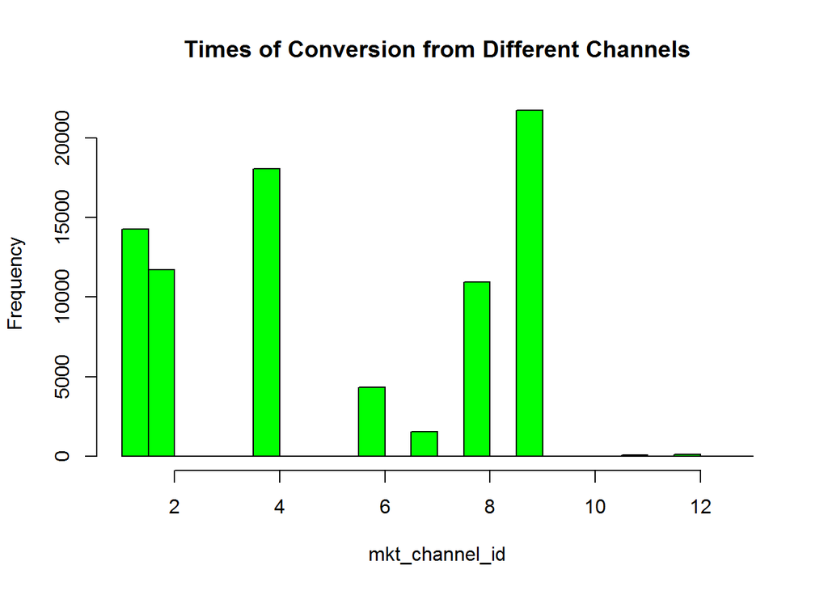

```r
histmkg <- journey$mkt_channel_id[journey$journey_event_type==1]
hist(histmkg,main = "Times of Conversion from Different Channels", xlab = "mkt_channel_id", col = "green")
```

```r
con10 <- sum(journey$mkt_channel_id[journey$journey_event_type==1]==10)
con11 <- sum(journey$mkt_channel_id[journey$journey_event_type==1]==11)
con12 <- sum(journey$mkt_channel_id[journey$journey_event_type==1]==12)
con9 <- sum(journey$mkt_channel_id[journey$journey_event_type==1]==9)
```

## histgram of journey_event_type of olddata

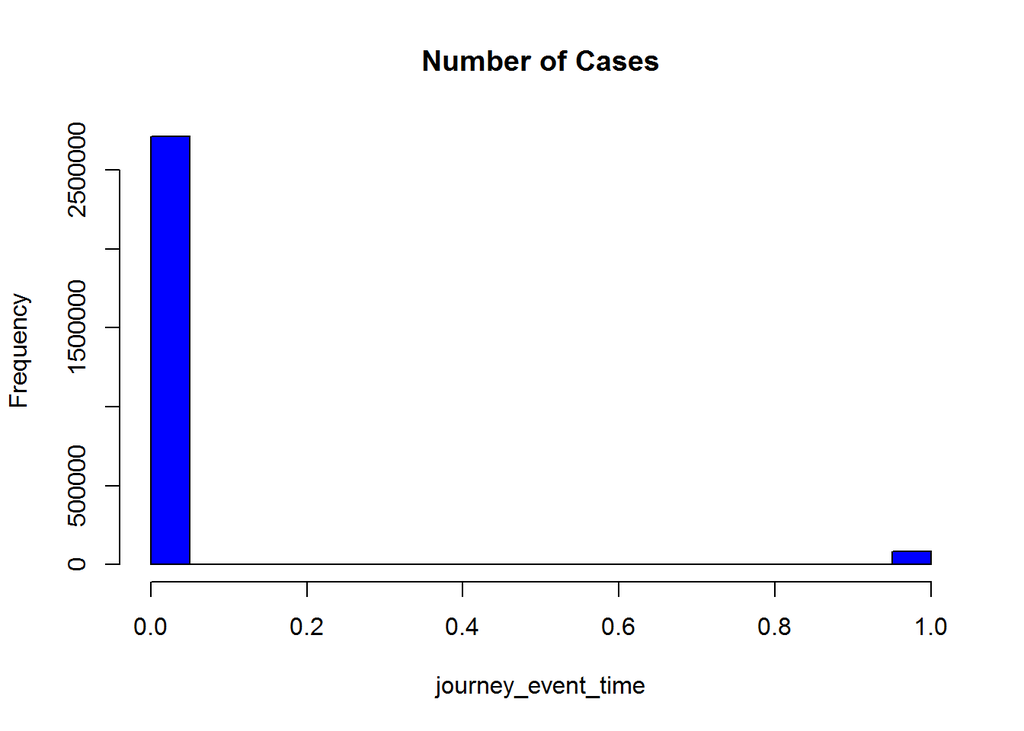

```r
histtype1 <- journey$journey_event_type
hist(histtype1,main = "Number of Cases", xlab = "journey_event_time", col = "blue")
```

## Boxplot of journey steps for different channels

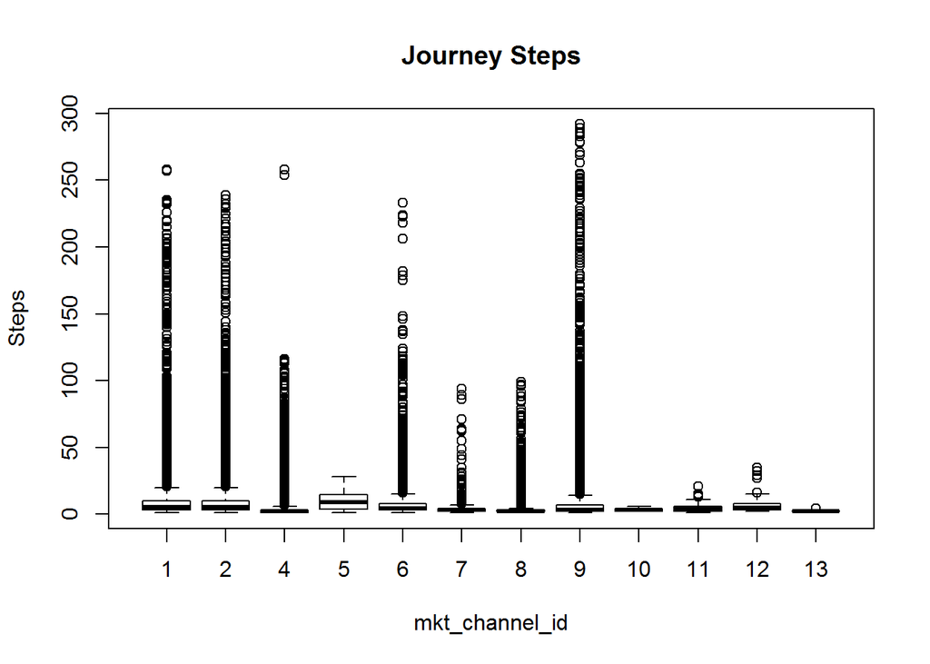

```r
conjourney <- journey[journey$journey_event_type==1,]
boxplot(journey_step~mkt_channel_id,data=conjourney, main="Journey Steps", xlab="mkt_channel_id", ylab="Steps")
```

Boxplot shows that journey steps vary for conversion from different channels. We may need to create new variables to show journey steps for different marketing channels.

## Create new variables for journey steps

```r
for (id in unique(journey$mkt_channel_id)) {
        channelstep <- data.frame(journey$journey_step)
        colnames(channelstep) <- paste('journey_step',id,sep='_')
        channelstep[journey$mkt_channel_id!=id,] <- 0
        journey <- cbind(journey,channelstep)
}
```

## Partition data in to train, test, validatian

```r
journey$journey_event_type <- factor(journey$journey_event_type)
journeydata <- journey[,c('X','journey_event_type','mkt_channel_id','journey_step_8','journey_step_1',
                          'journey_step_4','journey_step_9','journey_step_6','journey_step_7',
                          'journey_step_2','journey_step_11','journey_step_5','journey_step_10',
                          'journey_step_12','journey_step_13','journey_step_3')]
journeydata$mkt_channel_id <- factor(journeydata$mkt_channel_id)

library(caret)
set.seed(1234)
intrain <- createDataPartition(y=journeydata$journey_event_type,p=0.8,list=FALSE)
testdata <- journeydata[-intrain,]
testdata <- subset(testdata,select = -X)
training <- journeydata[intrain,]

intrain <- createDataPartition(y=training$journey_event_type,p=0.8,list=FALSE)
traindata <- training[intrain,]
validatedata <- training[-intrain,]
validatedata <- subset(validatedata,select= -X)
```

## Dataset is too large for the system to handle. Start with smaller dataset

```r
#set.seed(1234)
#small1 <- createDataPartition(y=traindata$journey_event_type,p=0.2,list=FALSE)
#traindata1 <- traindata[small1,]
#traindata1 <- subset(traindata1,select=-X)
#small1 <- createDataPartition(y=testdata$journey_event_type,p=0.2,list=FALSE)
#testdata1 <- testdata[small1,]
#testdata1 <- subset(testdata1,select=-X)
#small1 <- createDataPartition(y=validatedata$journey_event_type,p=0.2,list=FALSE)
#validatedata1 <- validatedata[small1,]
#validatedata1 <- subset(validatedata1,select=-X)
```

## Build a Generalized linear model

```r
#modelfit1 <- train(journey_event_type~.,data = traindata1,method='glm')
#prediction1 <- predict(modelfit1,newdata=validatedata1)
#table(prediction1,validatedata1$journey_event_type)
```

## Resample trainset to get balanced data.

```r
set.seed(1234)
traindata0 <- traindata[traindata$journey_event_type == 0,]
balance <- createDataPartition(y=traindata0$journey_event_type,p=0.975,list=FALSE)
retraindata <- traindata0[balance,]
btraindata <- traindata[!(traindata$X %in% retraindata$X),]
btraindata <- subset(btraindata, select = -X)
```

## histgram of journey_event_type of newdata

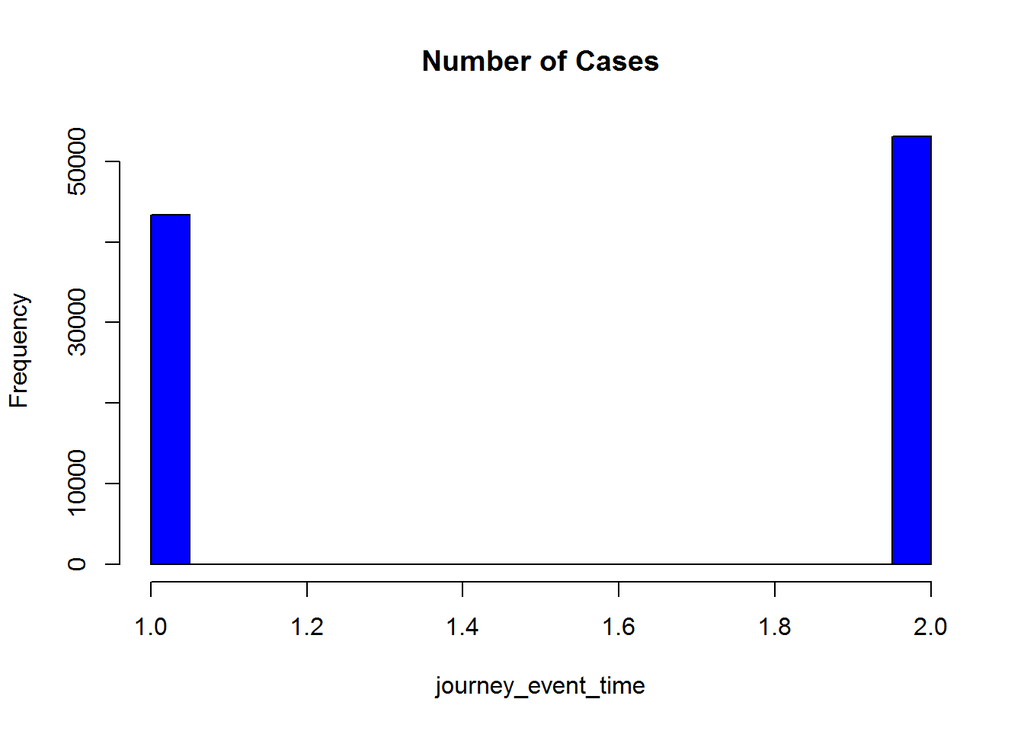

```r
histtype2 <- btraindata$journey_event_type
hist(as.numeric(histtype2),main = "Number of Cases", xlab = "journey_event_time", col = "blue")
```

## Build a Generalized linear model using balanced traindata

```r
modelfit01 <- train(journey_event_type~.,data = btraindata,method='glm')
prediction01 <- predict(modelfit01,newdata=validatedata)
confusionMatrix(prediction01,validatedata$journey_event_type)
```

```
## Confusion Matrix and Statistics
##
##           Reference
## Prediction      0      1
##          0 293266   4667
##          1 140435   8592
##
##                Accuracy : 0.6754
##                  95% CI : (0.674, 0.6767)
##     No Information Rate : 0.9703
##     P-Value [Acc > NIR] : 1
##
##                   Kappa : 0.0544
##  Mcnemar's Test P-Value : <2e-16
##
##             Sensitivity : 0.67619
##             Specificity : 0.64801
##          Pos Pred Value : 0.98434
##          Neg Pred Value : 0.05765
##              Prevalence : 0.97034
##          Detection Rate : 0.65613
##    Detection Prevalence : 0.66658
##       Balanced Accuracy : 0.66210
##
##        'Positive' Class : 0
##
```

## We only get 67.54% accuracy

## Plot the prediction for visualization

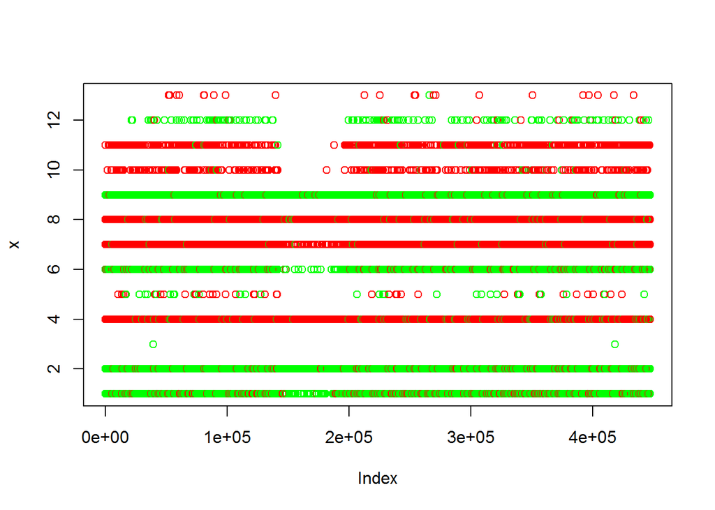

```r
color1 = factor(validatedata$journey_event_type==prediction01)
#validateplot = validatedata[c('mkt_channel_id','journey_step'),]
#validataplot$color1 = color1
plot(validatedata$mkt_channel_id,validatedata$journey_step,col=c('green','red')[color1])
```

## Build a decision tree model using balanced traindata

```r
modelfit2 <- train(journey_event_type~.,data = btraindata,method='rpart')
prediction2 <- predict(modelfit2,newdata=validatedata)
confusionMatrix(prediction2,validatedata$journey_event_type)
```

```
## Confusion Matrix and Statistics
##
##           Reference
## Prediction      0      1
##          0 289031   1247
##          1 144670  12012
##
##                Accuracy : 0.6735
##                  95% CI : (0.6722, 0.6749)
##     No Information Rate : 0.9703
##     P-Value [Acc > NIR] : 1
##
##                   Kappa : 0.0917
##  Mcnemar's Test P-Value : <2e-16
##
##             Sensitivity : 0.66643
##             Specificity : 0.90595
##          Pos Pred Value : 0.99570
##          Neg Pred Value : 0.07666
##              Prevalence : 0.97034
##          Detection Rate : 0.64666
##    Detection Prevalence : 0.64945
##       Balanced Accuracy : 0.78619
##
##        'Positive' Class : 0
##
```

## We get 67.35% accuracy

## Build a random forest model

```r
#control <- trainControl(method="repeatedcv", number=10, repeats=3)
#modelfit3 <- train(journey_event_type~.,data = btraindata,method='rf',matric="Accuracy",trControl=control)
#prediction3 <- predict(modelfit3,newdata=validatedata)
#confusionMatrix(prediction3,validatedata$journey_event_type)
```

## Build a regularized regression modle

```r
#modelfit4 <- train(journey_event_type~.,data = traindata,method='ridge',lambda=3.0)
#prediction4 <- predict(modelfit4,newdata=validatedata)
```